# Deserialization of Objects to a Workspace

# $X\to \pi^-\pi^+\pi^-$

Model definition: [`x2pipipi-compass-1391643.json`](https://github.com/RUB-EP1/amplitude-serialization/blob/main/models/x2pipipi-compass-1391643.json).

This page demonstrates deserialization and evaluation the a partial wave analysis of diffractively produced $3\pi$ system. The analysis is performed independently in bins of $3\pi$ mass, and transferred momentum. The total number of bins is 100. For every bin, the model includes about 170 decay chains (about 88 waves, symmetrized for two $\pi^+\pi^-$ pairs). The main paper describing details of the analysis is [INSPIRE-HEP 1391643](https://inspirehep.net/literature/1391643).

**Activate environment**

```julia
import Pkg
Pkg.activate(@__DIR__)
Pkg.instantiate()

using ThreeBodyDecaysIO
using ThreeBodyDecaysIO.ThreeBodyDecays
using ThreeBodyDecaysIO.HadronicLineshapes
using ThreeBodyDecaysIO.Parameters
using ThreeBodyDecaysIO.DataFrames
using ThreeBodyDecaysIO.JSON
using Measurements
using Statistics
using QuadGK
using Plots

theme(:wong2, frame=:box, grid=false, minorticks=true,
    guidefontvalign=:top, guidefonthalign=:right,
    foreground_color_legend=nothing,
    xlim=(:auto, :auto), ylim=(:auto, :auto),
    lab="")
```

Model components are deserialized from a JSON file into computational objects within a workspace for further manipulation. First, functions representing lineshapes and form factors are built. Following this, distributions are processed and added to the workspace.

**All `functions` and `distributution` are parsed here**

```julia
input = open(joinpath(@__DIR__, "..", "..", "models", "x2pipipi-compass-1391643.json")) do io
    JSON.parse(io)
end

workspace = Dict{String,Any}()

@unpack functions = input
for fn in functions
    @unpack name, type = fn
    instance_type = eval(Symbol(type))
    workspace[name] = dict2instance(instance_type, fn)
end

@unpack distributions = input
for dist in distributions
    @unpack name, type = dist
    instance_type = eval(Symbol(type))
    workspace[name] = dict2instance(instance_type, dist; workspace)
end
```

## Validation

The integrity of the model is checked by validating the value of distributions at a few phase space points. The table lists the validation checks and their status. The marks “🟢”, “🟡”, and “🔴” indicate an accuracy of $<10^{-10}$, $<10^{-2}$, or $\ge10^{-2}$, respectively, for the difference between the reference and computed values.

**A loop over validation points**

```julia
let
    @unpack misc, parameter_points = input
    @unpack amplitude_model_checksums = misc

    map(amplitude_model_checksums) do check_point_info
        @unpack point, value, distribution = check_point_info
        #
        # pull distribution
        dist = workspace[distribution]

        # pull correct parameter point
        parameter_points_dict = array2dict(parameter_points; key="name")
        # find the point in the list of points
        parameter_point = parameter_points_dict[point]
        # compute, compare
        _parameters = array2dict(parameter_point["parameters"];
            key="name", apply=v -> v["value"])
        #
        computed_value = dist(_parameters)
        #
        tonumber(X::Number) = X
        tonumber(X::String) = string2complex(X)
        reference_value = tonumber(value)
        status = label_diff(reference_value - computed_value; levels=[1e-2, 1e-10])
        #
        (; Distribution=distribution,
            Point=point, computed_value, value, Status=status)
    end |> DataFrame
end
```

21×5 DataFrame

| Row | Distribution String | Point String | computed_value Complex… | value Any | Status Char |
| --- | --- | --- | --- | --- | --- |
| 1 | compass_3pi_JP=1+_M=0_1540_1560 | validation_point1 | 0.557753+0.0im | 0.557753 | 🟢 |
| 2 | compass_3pi_JP=1+_M=0_1540_1560 | validation_point2 | 1.43625+0.0im | 1.43625 | 🟢 |
| 3 | compass_3pi_JP=1+_M=0_1540_1560 | validation_point3 | 0.108395+0.0im | 0.108395 | 🟢 |
| 4 | compass_3pi_JP=1+_M=0_1540_1560 | validation_point4 | 0.791847+0.0im | 0.791847 | 🟢 |
| 5 | compass_3pi_JP=1-_M=1_1540_1560 | validation_point1 | 0.0452047+0.0im | 0.0452047 | 🟢 |
| 6 | compass_3pi_JP=1-_M=1_1540_1560 | validation_point2 | 0.010651+0.0im | 0.010651 | 🟢 |
| 7 | compass_3pi_JP=1-_M=1_1540_1560 | validation_point3 | 0.01857+0.0im | 0.01857 | 🟢 |
| 8 | compass_3pi_JP=1-_M=1_1540_1560 | validation_point4 | 0.0900839+0.0im | 0.0900839 | 🟢 |
| 9 | compass_3pi_JP=2+_M=1_1540_1560 | validation_point1 | 0.0170822+0.0im | 0.0170822 | 🟢 |
| 10 | compass_3pi_JP=2+_M=1_1540_1560 | validation_point2 | 0.0579535+0.0im | 0.0579535 | 🟢 |
| 11 | compass_3pi_JP=2+_M=1_1540_1560 | validation_point3 | 0.035384+0.0im | 0.035384 | 🟢 |
| 12 | compass_3pi_JP=2+_M=1_1540_1560 | validation_point4 | 0.112218+0.0im | 0.112218 | 🟢 |
| 13 | compass_3pi_JP=4+_M=1_1540_1560 | validation_point1 | 0.0205558+0.0im | 0.0205558 | 🟢 |
| 14 | compass_3pi_JP=4+_M=1_1540_1560 | validation_point2 | 0.0118184+0.0im | 0.0118184 | 🟢 |
| 15 | compass_3pi_JP=4+_M=1_1540_1560 | validation_point3 | 0.0175504+0.0im | 0.0175504 | 🟢 |
| 16 | compass_3pi_JP=4+_M=1_1540_1560 | validation_point4 | 0.105833+0.0im | 0.105833 | 🟢 |
| 17 | R(1274) | validation_point_m12sq | 1.68268+0.620869im | 1.682682255119889 + 0.62086927105196i | 🟢 |
| 18 | R(1690) | validation_point_m12sq | 0.564308+0.103183im | 0.5643082293246228 + 0.10318283266108788i | 🟢 |
| 19 | R(600) | validation_point_m12sq | 0.101724+1.02734im | 0.10172436035046228 + 1.0273440332286132i | 🟢 |
| 20 | R(768) | validation_point_m12sq | -1.73218+0.632399im | -1.7321826562432676 + 0.6323990884902008i | 🟢 |
| 21 | R(965) | validation_point_m12sq | -0.921258+2.14704im | -0.9212576583634395 + 2.1470398931994485i | 🟢 |

## Visualization

The model describing the decay is fetched from the workspace

```julia
model_names = [k for (k, v) in workspace if v isa HadronicUnpolarizedIntensity]
```

```
4-element Vector{String}:
 "compass_3pi_JP=1+_M=0_1540_1560"
 "compass_3pi_JP=4+_M=1_1540_1560"
 "compass_3pi_JP=2+_M=1_1540_1560"
 "compass_3pi_JP=1-_M=1_1540_1560"
```

### Dalitz plot

The Dalitz plot shows the probability distribution across two dimensional phase space of the decay. Below the distribution is shown for all models in the file

**Dalitz plot plotting**

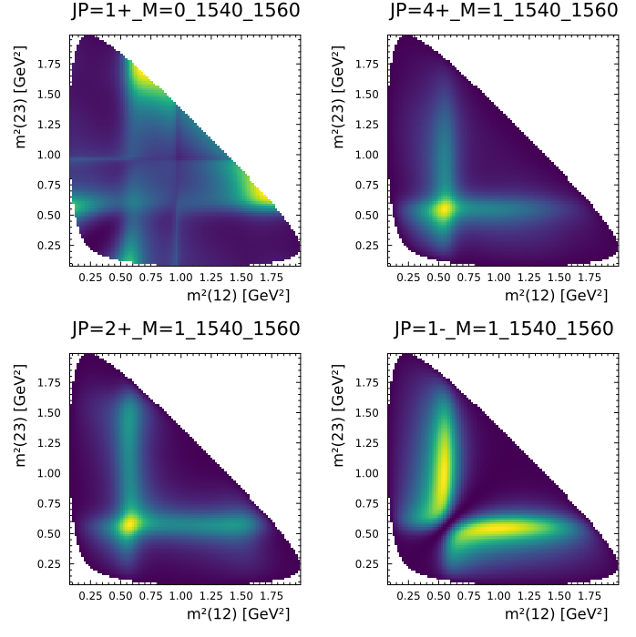

```julia
let iσx = 3, iσy = 1
    n_models = length(model_names)
    Nx, Ny = 2, div(n_models + 1, 2)
    plot(
        map(model_names) do model_name
            model = workspace[model_name].model
            #
            xlab = ((i, j) = ij_from_k(iσx);
            "m²($i$j) [GeV²]")
            ylab = ((i, j) = ij_from_k(iσy);
            "m²($i$j) [GeV²]")

            plot(masses(model), Base.Fix1(unpolarized_intensity, model);
                iσx, iσy, xlab, ylab, title=model_name[13:end], aspect_ratio=1)
        end...,
        layout=grid(Ny, Nx),
        size=(350 * Nx, 350 * Ny))
end
```